--- title: Forecasting Credit Default Using Predictive Analysis author: Jerry Yu, John Shiu, Sandra Gross, Hina Bandukwala date: 2023-12-27 format: html keep-ipynb: true ---

```python
# Initialize Otter
import otter
grader = otter.Notebook("lab4.ipynb")
```

# Lab 4: Putting it all together in a mini project

For this lab, **you can choose to work alone of in a group of up to four students**. You are in charge of how you want to work and who you want to work with. Maybe you really want to go through all the steps of the ML process yourself or maybe you want to practice your collaboration skills, it is up to you! Just remember to indicate who your group members are (if any) when you submit on Gradescope. If you choose to work in a group, you only need to use one GitHub repo (you can create one on github.ubc.ca and set the visibility to "public").

## Submission instructions

rubric={mechanics}

You receive marks for submitting your lab correctly, please follow these instructions:

- [Follow the general lab instructions.](https://ubc-mds.github.io/resources_pages/general_lab_instructions/)
- [Click here to view a description of the rubrics used to grade the questions](https://github.com/UBC-MDS/public/tree/master/rubric)
- Make at least three commits.
- Push your `.ipynb` file to your GitHub repository for this lab and upload it to Gradescope.
- Before submitting, make sure you restart the kernel and rerun all cells.
- Also upload a `.pdf` export of the notebook to facilitate grading of manual questions (preferably WebPDF, you can select two files when uploading to gradescope)
- Don't change any variable names that are given to you, don't move cells around, and don't include any code to install packages in the notebook.
- The data you download for this lab **SHOULD NOT BE PUSHED TO YOUR REPOSITORY** (there is also a `.gitignore` in the repo to prevent this).
- Include a clickable link to your GitHub repo for the lab just below this cell
  - It should look something like this https://github.ubc.ca/MDS-2020-21/DSCI_531_labX_yourcwl.

*Points:* 2

https://github.ubc.ca/hinab/DSCI_573_lab4

## Introduction

In this lab you will be working on an open-ended mini-project, where you will put all the different things you have learned so far in 571 and 573 together to solve an interesting problem.

A few notes and tips when you work on this mini-project:

#### Tips

1. Since this mini-project is open-ended there might be some situations where you'll have to use your own judgment and make your own decisions (as you would be doing when you work as a data scientist). Make sure you explain your decisions whenever necessary.
2. **Do not include everything you ever tried in your submission** -- it's fine just to have your final code. That said, your code should be reproducible and well-documented. For example, if you chose your hyperparameters based on some hyperparameter optimization experiment, you should leave in the code for that experiment so that someone else could re-run it and obtain the same hyperparameters, rather than mysteriously just setting the hyperparameters to some (carefully chosen) values in your code.
3. If you realize that you are repeating a lot of code try to organize it in functions. Clear presentation of your code, experiments, and results is the key to be successful in this lab. You may use code from lecture notes or previous lab solutions with appropriate attributions.

#### Assessment

We don't have some secret target score that you need to achieve to get a good grade. **You'll be assessed on demonstration of mastery of course topics, clear presentation, and the quality of your analysis and results.** For example, if you just have a bunch of code and no text or figures, that's not good. If you instead do a bunch of sane things and you have clearly motivated your choices, but still get lower model performance than your friend, don't sweat it.

#### A final note

Finally, the style of this "project" question is different from other assignments. It'll be up to you to decide when you're "done" -- in fact, this is one of the hardest parts of real projects. But please don't spend WAY too much time on this... perhaps "several hours" but not "many hours" is a good guideline for a high quality submission. Of course if you're having fun you're welcome to spend as much time as you want! But, if so, try not to do it out of perfectionism or getting the best possible grade. Do it because you're learning and enjoying it. Students from the past cohorts have found such kind of labs useful and fun and we hope you enjoy it as well.

## 1. Pick your problem and explain the prediction problem

rubric={reasoning}

In this mini project, you will pick one of the following problems:

1. A classification problem of predicting whether a credit card client will default or not. For this problem, you will use [Default of Credit Card Clients Dataset](https://www.kaggle.com/uciml/default-of-credit-card-clients-dataset). In this data set, there are 30,000 examples and 24 features, and the goal is to estimate whether a person will default (fail to pay) their credit card bills; this column is labeled "default.payment.next.month" in the data. The rest of the columns can be used as features. You may take some ideas and compare your results with [the associated research paper](https://www.sciencedirect.com/science/article/pii/S0957417407006719), which is available through [the UBC library](https://www.library.ubc.ca/).

OR

2. A regression problem of predicting `reviews_per_month`, as a proxy for the popularity of the listing with [New York City Airbnb listings from 2019 dataset](https://www.kaggle.com/dgomonov/new-york-city-airbnb-open-data). Airbnb could use this sort of model to predict how popular future listings might be before they are posted, perhaps to help guide hosts create more appealing listings. In reality they might instead use something like vacancy rate or average rating as their target, but we do not have that available here.

**Your tasks:**

1. Spend some time understanding the problem and what each feature means. Write a few sentences on your initial thoughts on the problem and the dataset.
2. Download the dataset and read it as a pandas dataframe.
3. Carry out any preliminary preprocessing, if needed (e.g., changing feature names, handling of NaN values etc.)

*Points:* 3

### Problem Statement

In this problem, we would like to predict whether a credit card client will default or not in the coming month or not, based on their demographic factors, credit data, history of payment, and bill statements in Taiwan from April 2005 to September 2005.

We are given a data set `UCI_Credit_Card.csv` which has 30,000 observations and 25 fields.

### Data Field Description

Below shows the description of each of the fields,

| Variable | Description |
| --- | --- |
| `ID` | ID of each client |
| `LIMIT_BAL` | Amount of given credit in NT dollars (includes individual and family/supplementary credit) |
| `SEX` | Gender (1=male, 2=female) |
| `EDUCATION` | (1=graduate school, 2=university, 3=high school, 4=others, 5=unknown, 6=unknown) |
| `MARRIAGE` | Marital status (1=married, 2=single, 3=others) |
| `AGE` | Age in years |
| `PAY_0` | Repayment status in September, 2005 (-2=No consumption, -1=pay duly, 0=The use of revolving credit, 1=payment delay for one month, 2=payment delay for two months, ..., 8=payment delay for eight months… |
| `PAY_2` | Repayment status in August, 2005 (scale same as above) |
| `PAY_3` | Repayment status in July, 2005 (scale same as above) |
| `PAY_4` | Repayment status in June, 2005 (scale same as above) |
| `PAY_5` | Repayment status in May, 2005 (scale same as above) |
| `PAY_6` | Repayment status in April, 2005 (scale same as above) |
| `BILL_AMT1` | Amount of bill statement in September, 2005 (NT dollar) |
| `BILL_AMT2` | Amount of bill statement in August, 2005 (NT dollar) |
| `BILL_AMT3` | Amount of bill statement in July, 2005 (NT dollar) |
| `BILL_AMT4` | Amount of bill statement in June, 2005 (NT dollar) |
| `BILL_AMT5` | Amount of bill statement in May, 2005 (NT dollar) |
| `BILL_AMT6` | Amount of bill statement in April, 2005 (NT dollar) |
| `PAY_AMT1` | Amount of previous payment in September, 2005 (NT dollar) |
| `PAY_AMT2` | Amount of previous payment in August, 2005 (NT dollar) |
| `PAY_AMT3` | Amount of previous payment in July, 2005 (NT dollar) |
| `PAY_AMT4` | Amount of previous payment in June, 2005 (NT dollar) |
| `PAY_AMT5` | Amount of previous payment in May, 2005 (NT dollar) |
| `PAY_AMT6` | Amount of previous payment in April, 2005 (NT dollar) |
| `default.payment.next.month` | Default payment (1=yes, 0=no) **(This will be our prediction target)** |

Reference:

- https://www.kaggle.com/datasets/uciml/default-of-credit-card-clients-dataset/data
- https://www.kaggle.com/datasets/uciml/default-of-credit-card-clients-dataset/discussion/34608

### Initial Thoughts

##### PAY_X variable

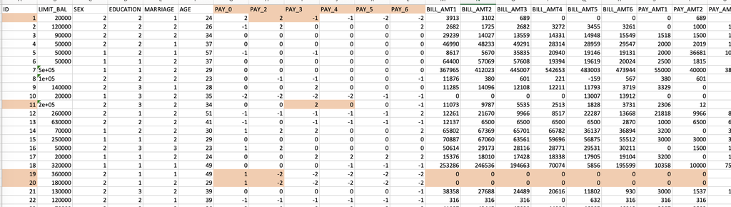

2. The name of one of the variables i.e. `PAY_0` is inconsistent with the naming convention used by other variables in the dataset i.e. `BILL_AMTX` and `PAY_AMTX`. We therefore think it would be more suitable to name it as `PAY_1` for consistency.

Therefore, we believe that there might be some problems in the data collection or data processing from the data creator. If possible, we would like to contact them (https://tw.linkedin.com/in/i-cheng-yeh-25ab2215, https://kamino.tru.ca/experts/home/main/bio.php?id=elien) for clarification before we could make good use of the `PAY_X` fields for our classification task.

##### Class Imbalance

3. In reality, we would expect the clients to usually pay on time in order to avoid late penalties, and hence, would also expect most of the observations to have `default.payment.next.month = 0`. We therefore expect the dataset to have a class imbalance.

```python
import shap
import numpy as np
import pandas as pd
import matplotlib.pyplot as plt
import altair as alt
alt.data_transformers.enable('vegafusion')

from scipy.stats import randint, loguniform

from sklearn.model_selection import train_test_split, cross_validate, RandomizedSearchCV
from sklearn.preprocessing import OneHotEncoder, OrdinalEncoder, StandardScaler
from sklearn.compose import make_column_transformer
from sklearn.pipeline import make_pipeline

from sklearn.metrics import classification_report
from sklearn.metrics import PrecisionRecallDisplay
from sklearn.metrics import ConfusionMatrixDisplay

from sklearn.feature_selection import RFECV

from sklearn.dummy import DummyClassifier
from sklearn.linear_model import LogisticRegression
from sklearn.neighbors import KNeighborsClassifier
from lightgbm import LGBMClassifier
from xgboost import XGBClassifier

from sklearn.inspection import permutation_importance
```

```python
def get_cv_table_from_searchCV(searchCV, round=3):
    # Extract the best result from searchCV, e.g. RandomizedSearchCV
    best_result = pd.DataFrame(searchCV.cv_results_).query('rank_test_score == 1')
    best_result = best_result[[
        'mean_fit_time', 'std_fit_time',
        'mean_score_time', 'std_score_time',
        'mean_test_score', 'std_test_score',
        'mean_train_score', 'std_train_score'
    ]].T.reset_index()

    # Parse mean_xxxx and std_xxxx into 2 columns
    names = pd.DataFrame(best_result['index'].str.split('_').tolist())
    best_result['stat'] = names[0]
    best_result['type'] = names[1] + '_' + names[2]
    best_result = best_result.drop(columns='index')

    # Format
    best_result = best_result.pivot(columns='stat', index='type')
    best_result.columns = ['mean', 'std']
    best_result.index.name = None

    return best_result.round(round)
```

```python
data = pd.read_csv("data/UCI_Credit_Card.csv")
```

## 2. Data splitting

rubric={reasoning}

**Your tasks:**

1. Split the data into train and test portions.

> Make the decision on the `test_size` based on the capacity of your laptop.

*Points:* 1

```python
train_df, test_df = train_test_split(data, test_size=0.25, random_state=101)

X_train = train_df.drop(columns="default.payment.next.month")
y_train = train_df["default.payment.next.month"]

X_test = test_df.drop(columns="default.payment.next.month")
y_test = test_df["default.payment.next.month"]
```

## 3. EDA

rubric={viz,reasoning}

Perform exploratory data analysis on the train set.

**Your tasks:**

1. Include at least two summary statistics and two visualizations that you find useful, and accompany each one with a sentence explaining it.
2. Summarize your initial observations about the data.
3. Pick appropriate metric/metrics for assessment.

*Points:* 6

```python
train_df.info()
```

```
<class 'pandas.core.frame.DataFrame'>
Index: 22500 entries, 20898 to 13151
Data columns (total 25 columns):
 #   Column                      Non-Null Count  Dtype
---  ------                      --------------  -----
 0   ID                          22500 non-null  int64
 1   LIMIT_BAL                   22500 non-null  float64
 2   SEX                         22500 non-null  int64
 3   EDUCATION                   22500 non-null  int64
 4   MARRIAGE                    22500 non-null  int64
 5   AGE                         22500 non-null  int64
 6   PAY_0                       22500 non-null  int64
 7   PAY_2                       22500 non-null  int64
 8   PAY_3                       22500 non-null  int64
 9   PAY_4                       22500 non-null  int64
```

[output cut: 17 more lines]

```python
# checking for class imbalance
class_imbalance = (
    alt.Chart(train_df)
    .mark_bar()
    .encode(
        x='count()',
        y=alt.Y('default\.payment\.next\.month:N').title('default.payment.next.month'))
    .properties(
        height=100
    )
)
class_imbalance
```

[interactive chart not shown]

```python
# Summary statistics
train_df.describe().T
```

|  | count | mean | std | min | 25% | 50% | 75% | max |
| --- | --- | --- | --- | --- | --- | --- | --- | --- |
| ID | 22500.0 | 14983.492533 | 8660.605639 | 2.0 | 7475.00 | 14980.5 | 22485.25 | 30000.0 |
| LIMIT_BAL | 22500.0 | 167601.496889 | 129843.786486 | 10000.0 | 50000.00 | 140000.0 | 240000.00 | 1000000.0 |
| SEX | 22500.0 | 1.605422 | 0.488771 | 1.0 | 1.00 | 2.0 | 2.00 | 2.0 |
| EDUCATION | 22500.0 | 1.852889 | 0.786545 | 0.0 | 1.00 | 2.0 | 2.00 | 6.0 |
| MARRIAGE | 22500.0 | 1.551511 | 0.521944 | 0.0 | 1.00 | 2.0 | 2.00 | 3.0 |
| AGE | 22500.0 | 35.484444 | 9.223782 | 21.0 | 28.00 | 34.0 | 41.00 | 79.0 |
| PAY_0 | 22500.0 | -0.015689 | 1.128908 | -2.0 | -1.00 | 0.0 | 0.00 | 8.0 |
| PAY_2 | 22500.0 | -0.133378 | 1.201114 | -2.0 | -1.00 | 0.0 | 0.00 | 8.0 |
| PAY_3 | 22500.0 | -0.162978 | 1.204599 | -2.0 | -1.00 | 0.0 | 0.00 | 8.0 |
| PAY_4 | 22500.0 | -0.215156 | 1.178376 | -2.0 | -1.00 | 0.0 | 0.00 | 8.0 |
| PAY_5 | 22500.0 | -0.261822 | 1.141148 | -2.0 | -1.00 | 0.0 | 0.00 | 8.0 |
| PAY_6 | 22500.0 | -0.287644 | 1.157309 | -2.0 | -1.00 | 0.0 | 0.00 | 8.0 |
| BILL_AMT1 | 22500.0 | 51348.428044 | 73854.672882 | -154973.0 | 3522.50 | 22344.5 | 67719.75 | 964511.0 |
| BILL_AMT2 | 22500.0 | 49355.000089 | 71479.837848 | -69777.0 | 2998.50 | 21085.5 | 64660.50 | 983931.0 |
| BILL_AMT3 | 22500.0 | 47247.063467 | 69897.969088 | -157264.0 | 2728.00 | 20031.5 | 60767.75 | 1664089.0 |
| BILL_AMT4 | 22500.0 | 43565.190356 | 64744.571220 | -81334.0 | 2360.00 | 19082.0 | 54998.50 | 891586.0 |
| BILL_AMT5 | 22500.0 | 40602.313067 | 61177.874092 | -81334.0 | 1795.50 | 18153.5 | 50377.75 | 927171.0 |
| BILL_AMT6 | 22500.0 | 39112.334400 | 60068.761295 | -209051.0 | 1238.00 | 16987.5 | 49316.25 | 961664.0 |
| PAY_AMT1 | 22500.0 | 5753.534578 | 16999.747958 | 0.0 | 1000.00 | 2120.5 | 5024.00 | 873552.0 |
| PAY_AMT2 | 22500.0 | 6042.993600 | 24758.230771 | 0.0 | 824.75 | 2013.0 | 5000.00 | 1684259.0 |
| PAY_AMT3 | 22500.0 | 5333.721911 | 18320.303109 | 0.0 | 390.00 | 1800.0 | 4541.25 | 896040.0 |
| PAY_AMT4 | 22500.0 | 4832.115289 | 15460.744513 | 0.0 | 292.00 | 1500.0 | 4021.25 | 621000.0 |
| PAY_AMT5 | 22500.0 | 4825.513867 | 15541.867113 | 0.0 | 253.25 | 1500.0 | 4071.25 | 426529.0 |
| PAY_AMT6 | 22500.0 | 5323.880133 | 18124.267122 | 0.0 | 114.75 | 1500.0 | 4000.00 | 528666.0 |
| default.payment.next.month | 22500.0 | 0.222711 | 0.416075 | 0.0 | 0.00 | 0.0 | 0.00 | 1.0 |

```python
# Correlation matrix for numerics
numerical_df = train_df.select_dtypes(include = 'number')
numerical_df = numerical_df.drop(['SEX', 'ID', 'EDUCATION', 'MARRIAGE'], axis=1)
numerical_df.corr('pearson').round(3).style.format('{:.3f}').background_gradient(cmap = 'YlGnBu')
```

|  | LIMIT_BAL | AGE | PAY_0 | PAY_2 | PAY_3 | PAY_4 | PAY_5 | PAY_6 | BILL_AMT1 | BILL_AMT2 | BILL_AMT3 | BILL_AMT4 | BILL_AMT5 | BILL_AMT6 | PAY_AMT1 | PAY_AMT2 | PAY_AMT3 | PAY_AMT4 | PAY_AMT5 | PAY_AMT6 | default.payment.next.month |
| --- | --- | --- | --- | --- | --- | --- | --- | --- | --- | --- | --- | --- | --- | --- | --- | --- | --- | --- | --- | --- | --- |
| LIMIT_BAL | 1.000 | 0.137 | -0.275 | -0.297 | -0.286 | -0.267 | -0.248 | -0.231 | 0.290 | 0.282 | 0.288 | 0.301 | 0.300 | 0.294 | 0.197 | 0.174 | 0.214 | 0.205 | 0.221 | 0.223 | -0.154 |
| AGE | 0.137 | 1.000 | -0.037 | -0.047 | -0.046 | -0.044 | -0.050 | -0.046 | 0.057 | 0.054 | 0.052 | 0.051 | 0.049 | 0.047 | 0.029 | 0.018 | 0.027 | 0.017 | 0.013 | 0.018 | 0.018 |
| PAY_0 | -0.275 | -0.037 | 1.000 | 0.675 | 0.577 | 0.539 | 0.510 | 0.478 | 0.190 | 0.192 | 0.180 | 0.180 | 0.182 | 0.177 | -0.081 | -0.070 | -0.069 | -0.067 | -0.058 | -0.062 | 0.327 |
| PAY_2 | -0.297 | -0.047 | 0.675 | 1.000 | 0.770 | 0.668 | 0.630 | 0.582 | 0.236 | 0.238 | 0.226 | 0.224 | 0.224 | 0.221 | -0.081 | -0.059 | -0.055 | -0.050 | -0.038 | -0.038 | 0.264 |
| PAY_3 | -0.286 | -0.046 | 0.577 | 0.770 | 1.000 | 0.779 | 0.691 | 0.639 | 0.210 | 0.238 | 0.229 | 0.229 | 0.229 | 0.224 | -0.005 | -0.065 | -0.052 | -0.046 | -0.037 | -0.039 | 0.238 |
| PAY_4 | -0.267 | -0.044 | 0.539 | 0.668 | 0.779 | 1.000 | 0.825 | 0.721 | 0.203 | 0.226 | 0.244 | 0.245 | 0.243 | 0.238 | -0.014 | -0.005 | -0.067 | -0.047 | -0.036 | -0.029 | 0.218 |
| PAY_5 | -0.248 | -0.050 | 0.510 | 0.630 | 0.691 | 0.825 | 1.000 | 0.818 | 0.208 | 0.227 | 0.242 | 0.272 | 0.270 | 0.262 | -0.009 | -0.005 | 0.006 | -0.059 | -0.036 | -0.025 | 0.206 |
| PAY_6 | -0.231 | -0.046 | 0.478 | 0.582 | 0.639 | 0.721 | 0.818 | 1.000 | 0.210 | 0.229 | 0.242 | 0.268 | 0.292 | 0.286 | -0.003 | -0.005 | 0.005 | 0.018 | -0.048 | -0.027 | 0.191 |
| BILL_AMT1 | 0.290 | 0.057 | 0.190 | 0.236 | 0.210 | 0.203 | 0.208 | 0.210 | 1.000 | 0.952 | 0.892 | 0.864 | 0.834 | 0.806 | 0.148 | 0.096 | 0.163 | 0.160 | 0.168 | 0.178 | -0.015 |
| BILL_AMT2 | 0.282 | 0.054 | 0.192 | 0.238 | 0.238 | 0.226 | 0.227 | 0.229 | 0.952 | 1.000 | 0.925 | 0.894 | 0.863 | 0.834 | 0.279 | 0.097 | 0.156 | 0.151 | 0.158 | 0.167 | -0.009 |
| BILL_AMT3 | 0.288 | 0.052 | 0.180 | 0.226 | 0.229 | 0.244 | 0.242 | 0.242 | 0.892 | 0.925 | 1.000 | 0.922 | 0.884 | 0.853 | 0.240 | 0.320 | 0.129 | 0.148 | 0.186 | 0.177 | -0.009 |
| BILL_AMT4 | 0.301 | 0.051 | 0.180 | 0.224 | 0.229 | 0.245 | 0.272 | 0.268 | 0.864 | 0.894 | 0.922 | 1.000 | 0.943 | 0.903 | 0.237 | 0.200 | 0.306 | 0.143 | 0.164 | 0.172 | -0.007 |
| BILL_AMT5 | 0.300 | 0.049 | 0.182 | 0.224 | 0.229 | 0.243 | 0.270 | 0.292 | 0.834 | 0.863 | 0.884 | 0.943 | 1.000 | 0.946 | 0.218 | 0.172 | 0.260 | 0.292 | 0.142 | 0.154 | -0.003 |
| BILL_AMT6 | 0.294 | 0.047 | 0.177 | 0.221 | 0.224 | 0.238 | 0.262 | 0.286 | 0.806 | 0.834 | 0.853 | 0.903 | 0.946 | 1.000 | 0.199 | 0.166 | 0.242 | 0.250 | 0.306 | 0.105 | -0.001 |
| PAY_AMT1 | 0.197 | 0.029 | -0.081 | -0.081 | -0.005 | -0.014 | -0.009 | -0.003 | 0.148 | 0.279 | 0.240 | 0.237 | 0.218 | 0.199 | 1.000 | 0.310 | 0.282 | 0.222 | 0.148 | 0.183 | -0.072 |
| PAY_AMT2 | 0.174 | 0.018 | -0.070 | -0.059 | -0.065 | -0.005 | -0.005 | -0.005 | 0.096 | 0.097 | 0.320 | 0.200 | 0.172 | 0.166 | 0.310 | 1.000 | 0.258 | 0.196 | 0.189 | 0.167 | -0.058 |
| PAY_AMT3 | 0.214 | 0.027 | -0.069 | -0.055 | -0.052 | -0.067 | 0.006 | 0.005 | 0.163 | 0.156 | 0.129 | 0.306 | 0.260 | 0.242 | 0.282 | 0.258 | 1.000 | 0.243 | 0.157 | 0.174 | -0.058 |
| PAY_AMT4 | 0.205 | 0.017 | -0.067 | -0.050 | -0.046 | -0.047 | -0.059 | 0.018 | 0.160 | 0.151 | 0.148 | 0.143 | 0.292 | 0.250 | 0.222 | 0.196 | 0.243 | 1.000 | 0.154 | 0.171 | -0.053 |
| PAY_AMT5 | 0.221 | 0.013 | -0.058 | -0.038 | -0.037 | -0.036 | -0.036 | -0.048 | 0.168 | 0.158 | 0.186 | 0.164 | 0.142 | 0.306 | 0.148 | 0.189 | 0.157 | 0.154 | 1.000 | 0.146 | -0.056 |
| PAY_AMT6 | 0.223 | 0.018 | -0.062 | -0.038 | -0.039 | -0.029 | -0.025 | -0.027 | 0.178 | 0.167 | 0.177 | 0.172 | 0.154 | 0.105 | 0.183 | 0.167 | 0.174 | 0.171 | 0.146 | 1.000 | -0.054 |
| default.payment.next.month | -0.154 | 0.018 | 0.327 | 0.264 | 0.238 | 0.218 | 0.206 | 0.191 | -0.015 | -0.009 | -0.009 | -0.007 | -0.003 | -0.001 | -0.072 | -0.058 | -0.058 | -0.053 | -0.056 | -0.054 | 1.000 |

```python
# Distribution of features
categorical_cols = ["SEX", "MARRIAGE", "EDUCATION"]
ordinal_cols = ["PAY_0", "PAY_2", "PAY_3", "PAY_4", "PAY_5", "PAY_6"]

numeric_cols = [
    'LIMIT_BAL', 'AGE',
    'BILL_AMT1', 'BILL_AMT2', 'BILL_AMT3', 'BILL_AMT4', 'BILL_AMT5', 'BILL_AMT6',
    'PAY_AMT1', 'PAY_AMT2', 'PAY_AMT3', 'PAY_AMT4', 'PAY_AMT5', 'PAY_AMT6'
]

drop_cols = ["ID"]


train_df["default.payment.next.month"] = train_df["default.payment.next.month"].astype('category')

def plot_histogram(df, col_name, maxbins):
    """
    Plots the histogram of a numerical column in the dataset
    """
    plot = alt.Chart(df).mark_bar().encode(
        alt.X(col_name).type('quantitative').bin(maxbins=maxbins),
        y='count()',
        color=alt.Color('default\.payment\.next\.month').title('default.payment.next.month')
    ).properties(
        width=300,
        height=200
    )
    return plot

maxbins = [30] * 7
plots = []
for col, maxbin in zip(numeric_cols, maxbins):
    plots.append(plot_histogram(train_df, col, maxbin))

alt.vconcat(*plots)
```

[interactive chart not shown]

```python
remaining_cols = numeric_cols[-3:]

maxbins = [30] * 3
plots = []
for col, maxbin in zip(remaining_cols, maxbins):
    plots.append(plot_histogram(train_df, col, maxbin))

alt.vconcat(*plots)
```

[interactive chart not shown]

## 4. Feature engineering (Challenging)

rubric={reasoning}

**Your tasks:**

1. Carry out feature engineering. In other words, extract new features relevant for the problem and work with your new feature set in the following exercises. You may have to go back and forth between feature engineering and preprocessing.

*Points:* 0.5

The Payment Coverage Ratio is a feature derived by dividing the feature PAY_AMT_{X-1} by BILL_AMT_{X}. This ratio describes the amount the person paid relative to their monthly bill amount. A ratio of 1 indicates a perfect score as they paid off their bill entirely. A ratio of 0 indicates that the person did not pay anything of the bill and is therefore the "worst" ratio. A person who paid more than their bill amount would have a ratio greater than 1. The special case here is when a person does not have any amount to pay for a certain month. This is indicated by the ratio 1 and therefore treated equally to someone with a perfect ratio. In our data set we call this new variables 'pay_to_bill'. For this newly created variable, we only include the average, standard deviation, and the ratio of average over standard deviation. This is to gauge overall behavior across all periods, with the anticipation that a significant deviation from this ratio is unlikely for a creditworthy customer.

#### Payment Coverage Ratio

```python
for i in range(2, 7):
    data[f'pay_to_bill_{i}'] = np.where(data[f'BILL_AMT{i}'] <= 0, 1, data[f'PAY_AMT{i-1}'] / data[f'BILL_AMT{i}'])

tmp = data[['ID', 'pay_to_bill_2', 'pay_to_bill_3', 'pay_to_bill_4', 'pay_to_bill_5', 'pay_to_bill_6']].melt(id_vars='ID')
tmp['not_settle'] = (tmp['value'] < 1).astype(int)

tmp = tmp.groupby('ID').agg({
    'value': ['mean', 'std'],
    'not_settle': 'sum'
}).reset_index()
```

```python
tmp.columns = ['ID', 'pay_to_bill_avg', 'pay_to_bill_std', 'not_settle_count']

data = data.merge(tmp, how='left', on='ID')

# NOTE: added an 0.01 to avoid the dominator from being 0
data['pay_to_bill_sharpe'] = np.where(
    data['pay_to_bill_std'] == 0, 0, data['pay_to_bill_avg'] / (0.01 + data['pay_to_bill_std'])
)

data.head()
```

|  | ID | LIMIT_BAL | SEX | EDUCATION | MARRIAGE | AGE | PAY_0 | PAY_2 | PAY_3 | PAY_4 | ... | default.payment.next.month | pay_to_bill_2 | pay_to_bill_3 | pay_to_bill_4 | pay_to_bill_5 | pay_to_bill_6 | pay_to_bill_avg | pay_to_bill_std | not_settle_count | pay_to_bill_sharpe |
| --- | --- | --- | --- | --- | --- | --- | --- | --- | --- | --- | --- | --- | --- | --- | --- | --- | --- | --- | --- | --- | --- |
| 0 | 1 | 20000.0 | 2 | 2 | 1 | 24 | 2 | 2 | -1 | -1 | ... | 1 | 0.000000 | 1.000000 | 1.000000 | 1.000000 | 1.000000 | 0.800000 | 0.447214 | 1 | 1.749729 |
| 1 | 2 | 120000.0 | 2 | 2 | 2 | 26 | -1 | 2 | 0 | 0 | ... | 1 | 0.000000 | 0.372856 | 0.305623 | 0.289436 | 0.000000 | 0.193583 | 0.179463 | 5 | 1.021744 |
| 2 | 3 | 90000.0 | 2 | 2 | 2 | 34 | 0 | 0 | 0 | 0 | ... | 0 | 0.108220 | 0.110628 | 0.069779 | 0.066899 | 0.064313 | 0.083968 | 0.023334 | 5 | 2.518971 |
| 3 | 4 | 50000.0 | 2 | 2 | 1 | 37 | 0 | 0 | 0 | 0 | ... | 0 | 0.041465 | 0.040961 | 0.042382 | 0.037985 | 0.036180 | 0.039794 | 0.002607 | 5 | 3.156501 |
| 4 | 5 | 50000.0 | 1 | 2 | 1 | 57 | -1 | 0 | -1 | 0 | ... | 0 | 0.352734 | 1.023608 | 0.477555 | 0.470072 | 0.036015 | 0.471997 | 0.356586 | 4 | 1.287548 |

5 rows × 34 columns

#### `PAY_X` Cleaning and Binning

```python
# Clean the column name
data['PAY_1'] = data['PAY_0']

# Bin the PAY_X: (-2, -1) -> duly; (0) -> credit; (1, 2, ..., 9) -> delay
for i in range(1, 7):
    data[f'PAY_{i}_split'] = np.where(
        data[f'PAY_{i}'] < 0, 'duly',
        np.where(
            data[f'PAY_{i}'] == 0, 'credit',
            'delay'
        )
    )

tmp = data[['ID', 'PAY_1_split',	'PAY_2_split', 'PAY_3_split', 'PAY_4_split', 'PAY_5_split', 'PAY_6_split']].melt(id_vars='ID')

tmp = tmp.groupby(['ID', 'value']).count()
tmp = tmp.reset_index(['ID', 'value']).pivot(index='ID', columns='value').fillna(0).reset_index()
tmp.columns = ['ID', 'credit_count', 'delay_count', 'duly_count']

data = data.merge(tmp, how='left', on='ID')
```

```python
tmp
```

|  | ID | credit_count | delay_count | duly_count |
| --- | --- | --- | --- | --- |
| 0 | 1 | 0.0 | 2.0 | 4.0 |
| 1 | 2 | 3.0 | 2.0 | 1.0 |
| 2 | 3 | 6.0 | 0.0 | 0.0 |
| 3 | 4 | 6.0 | 0.0 | 0.0 |
| 4 | 5 | 4.0 | 0.0 | 2.0 |
| ... | ... | ... | ... | ... |
| 29995 | 29996 | 6.0 | 0.0 | 0.0 |
| 29996 | 29997 | 2.0 | 0.0 | 4.0 |
| 29997 | 29998 | 2.0 | 3.0 | 1.0 |
| 29998 | 29999 | 3.0 | 1.0 | 2.0 |
| 29999 | 30000 | 6.0 | 0.0 | 0.0 |

30000 rows × 4 columns

As highlighted in the Initial Thoughts Section, we observed anomalous behavior in the PAY_ variables, indicative of a systematic error within these variables. To minimize this systematic error, we opt to categorize these variables by binning them into three groups based on their feature values. Value less than zero are labelled as 'duly', i.e. they pay on time. If the value is equal to zero, the person has cleared the minimum payment. All other value imply that there is a delay in payment. Out of these binned groups we build other 3 variables by counting the respective values, namely `credit_count`, `delay_count` and `duly_count`.

### Split data again after feature engineering

After having created new features and removed some of the existing ones, we need to split our data again:

```python
train_df, test_df = train_test_split(data, test_size=0.25, random_state=101)

X_train = train_df.drop(columns="default.payment.next.month")
y_train = train_df["default.payment.next.month"]

X_test = test_df.drop(columns="default.payment.next.month")
y_test = test_df["default.payment.next.month"]
X_train.head()
```

|  | ID | LIMIT_BAL | SEX | EDUCATION | MARRIAGE | AGE | PAY_0 | PAY_2 | PAY_3 | PAY_4 | ... | PAY_1 | PAY_1_split | PAY_2_split | PAY_3_split | PAY_4_split | PAY_5_split | PAY_6_split | credit_count | delay_count | duly_count |
| --- | --- | --- | --- | --- | --- | --- | --- | --- | --- | --- | --- | --- | --- | --- | --- | --- | --- | --- | --- | --- | --- |
| 20898 | 20899 | 200000.0 | 1 | 2 | 2 | 25 | -1 | 0 | 0 | 0 | ... | -1 | duly | credit | credit | credit | credit | credit | 5.0 | 0.0 | 1.0 |
| 24535 | 24536 | 50000.0 | 1 | 2 | 2 | 39 | 0 | 0 | 0 | 0 | ... | 0 | credit | credit | credit | credit | credit | delay | 5.0 | 1.0 | 0.0 |
| 25096 | 25097 | 20000.0 | 1 | 3 | 2 | 53 | -1 | 0 | -1 | -1 | ... | -1 | duly | credit | duly | duly | duly | duly | 1.0 | 0.0 | 5.0 |
| 6506 | 6507 | 50000.0 | 1 | 2 | 2 | 52 | 1 | 2 | 0 | 0 | ... | 1 | delay | delay | credit | credit | credit | delay | 3.0 | 3.0 | 0.0 |
| 11421 | 11422 | 140000.0 | 1 | 3 | 1 | 35 | 0 | 0 | 0 | -2 | ... | 0 | credit | credit | credit | duly | duly | duly | 3.0 | 0.0 | 3.0 |

5 rows × 43 columns

## 5. Preprocessing and transformations

rubric={accuracy,reasoning}

**Your tasks:**

1. Identify different feature types and the transformations you would apply on each feature type.
2. Define a column transformer, if necessary.

*Points:* 4

```python
# 1. Identify different feature types and the transformations you would apply on each feature type.
numeric_features = ['LIMIT_BAL', 'AGE', 'pay_to_bill_avg', 'pay_to_bill_std', 'pay_to_bill_sharpe']

categorical_features = ['SEX', 'EDUCATION', 'MARRIAGE']

ordinal_ordering = {
    'not_settle_count': [0, 1, 2, 3, 4, 5],
    'credit_count': [0, 1, 2, 3, 4, 5, 6],
    'delay_count': [0, 1, 2, 3, 4, 5, 6],
    'PAY_1': [-2, -1, 0, 1, 2, 3, 4, 5, 6, 7, 8, 9]
}
ordinal_features = list(ordinal_ordering.keys())

drop_features = [
    "ID",
    "PAY_0", "PAY_2", "PAY_3",	"PAY_4", "PAY_5", "PAY_6",
    "BILL_AMT1", "BILL_AMT2", "BILL_AMT3", "BILL_AMT4", "BILL_AMT5", "BILL_AMT6",
    "PAY_AMT1", "PAY_AMT2", "PAY_AMT3", "PAY_AMT4", "PAY_AMT5", "PAY_AMT6",
    "pay_to_bill_6", "pay_to_bill_5", "pay_to_bill_4", "pay_to_bill_3", "pay_to_bill_2",
    "PAY_1_split", "PAY_2_split", "PAY_3_split", "PAY_4_split", "PAY_5_split", "PAY_6_split",
    "duly_count"
]
```

```python
# 2. Define a column transformer
preprocessor = make_column_transformer(
    ("drop", drop_features),
    (StandardScaler(), numeric_features),
    (OneHotEncoder(drop="if_binary", handle_unknown="ignore", sparse_output=False), categorical_features),
    (OrdinalEncoder(categories=list(ordinal_ordering.values()), handle_unknown="error"), ordinal_features)
)
```

## 6. Baseline model

rubric={accuracy}

**Your tasks:**

1. Train a baseline model for your task and report its performance.

*Points:* 2

```python
dummy_pipe = make_pipeline(preprocessor, DummyClassifier())

pd.DataFrame(
    cross_validate(
        dummy_pipe,
        X_train,
        y_train,
        return_train_score=True,
        scoring="f1"
    )
).agg(['mean', 'std']).round(3).T
```

|  | mean | std |
| --- | --- | --- |
| fit_time | 0.014 | 0.003 |
| score_time | 0.004 | 0.000 |
| test_score | 0.000 | 0.000 |
| train_score | 0.000 | 0.000 |

## 7. Linear models

rubric={accuracy,reasoning}

**Your tasks:**

1. Try a linear model as a first real attempt.
2. Carry out hyperparameter tuning to explore different values for the regularization hyperparameter.
3. Report cross-validation scores along with standard deviation.
4. Summarize your results.

*Points:* 8

```python
# 1. Try Logistic Regression (a linear model) as a first real attempt.
lr_pipe = make_pipeline(preprocessor, LogisticRegression(max_iter=2000))

pd.DataFrame(
    cross_validate(
        lr_pipe,
        X_train,
        y_train,
        return_train_score=True,
        scoring="f1"
    )
).agg(['mean', 'std']).round(3).T
```

|  | mean | std |
| --- | --- | --- |
| fit_time | 0.148 | 0.015 |
| score_time | 0.004 | 0.000 |
| test_score | 0.396 | 0.010 |
| train_score | 0.399 | 0.003 |

```python
# 2. Carry out hyperparameter tuning to explore different values for the regularization hyperparameter.

param_dist = {
    "logisticregression__C": loguniform(1e-3, 1e3),
    "logisticregression__class_weight": [None, "balanced"],
}

rs = RandomizedSearchCV(
    lr_pipe,
    param_dist,
    n_iter=20,
    scoring="f1",
    return_train_score=True,
    random_state=123
)
rs.fit(X_train, y_train)

# Best hyperparameters
rs.best_params_
```

```
{'logisticregression__C': 124.90814664816953,
 'logisticregression__class_weight': 'balanced'}
```

```python
# 3. Report cross-validation scores along with standard deviation.
lr_pipe = rs.best_estimator_ # best model

get_cv_table_from_searchCV(rs, round=3)
```

|  | mean | std |
| --- | --- | --- |
| fit_time | 0.233 | 0.031 |
| score_time | 0.004 | 0.000 |
| test_score | 0.525 | 0.011 |
| train_score | 0.527 | 0.002 |

**4. Summarize the results.** We observe that logistic regression, without prior hyperparameter optimization, yields an F1 score of 0.396 on the validation set. Through optimizing the hyperparameters C and adjusting the class weight argument, we significantly enhance our F1 score to 0.525. The optimal parameters involve a C value of almost 125 and a balanced class weight to address the underrepresentation of a specific class.

## 8. Different models

rubric={accuracy,reasoning}

**Your tasks:**

1. Try out three other models aside from the linear model.
2. Summarize your results in terms of overfitting/underfitting and fit and score times. Can you beat the performance of the linear model?

*Points:* 10

```python
# 1) LightGBM
lgbm_pipe = make_pipeline(preprocessor, LGBMClassifier(verbose=-1))

pd.DataFrame(
    cross_validate(
        lgbm_pipe,
        X_train,
        y_train,
        return_train_score=True,
        scoring="f1"
    )
).agg(['mean', 'std']).round(3).T
```

|  | mean | std |
| --- | --- | --- |
| fit_time | 0.316 | 0.017 |
| score_time | 0.009 | 0.001 |
| test_score | 0.470 | 0.014 |
| train_score | 0.542 | 0.005 |

```python
# 2) XGBoost
xgb_pipe = make_pipeline(preprocessor, XGBClassifier())

pd.DataFrame(
    cross_validate(
        xgb_pipe,
        X_train,
        y_train,
        return_train_score=True,
        scoring="f1"
    )
).agg(['mean', 'std']).round(3).T
```

|  | mean | std |
| --- | --- | --- |
| fit_time | 0.130 | 0.005 |
| score_time | 0.006 | 0.001 |
| test_score | 0.458 | 0.013 |
| train_score | 0.647 | 0.007 |

```python
# 3) k-NN
knn_pipe = make_pipeline(preprocessor, KNeighborsClassifier())

pd.DataFrame(
    cross_validate(
        knn_pipe,
        X_train,
        y_train,
        return_train_score=True,
        scoring="f1"
    )
).agg(['mean', 'std']).round(3).T
```

|  | mean | std |
| --- | --- | --- |
| fit_time | 0.013 | 0.000 |
| score_time | 0.065 | 0.015 |
| test_score | 0.439 | 0.013 |
| train_score | 0.569 | 0.005 |

## 9. Feature selection (Challenging)

rubric={reasoning}

**Your tasks:**

Make some attempts to select relevant features. You may try `RFECV`, forward/backward selection or L1 regularization for this. Do the results improve with feature selection? Summarize your results. If you see improvements in the results, keep feature selection in your pipeline. If not, you may abandon it in the next exercises unless you think there are other benefits with using less features.

*Points:* 0.5

```python
# RFECV + LightGBM
rfecv_lgbm_pipe = make_pipeline(
    preprocessor,
    RFECV(LogisticRegression(max_iter=2000)),
    LGBMClassifier(verbose=-1)
)

pd.DataFrame(
    cross_validate(
        rfecv_lgbm_pipe,
        X_train,
        y_train,
        return_train_score=True,
        scoring="f1"
    )
).agg(['mean', 'std']).round(3).T
```

|  | mean | std |
| --- | --- | --- |
| fit_time | 6.699 | 0.216 |
| score_time | 0.009 | 0.001 |
| test_score | 0.442 | 0.014 |
| train_score | 0.444 | 0.004 |

**Summary**

In terms of validation score, the performance dropped from 0.470 to 0.442. Therefore, feature selection will be abandoned for the following exercises.

## 10. Hyperparameter optimization

rubric={accuracy,reasoning}

**Your tasks:**

Make some attempts to optimize hyperparameters for the models you've tried and summarize your results. In at least one case you should be optimizing multiple hyperparameters for a single model. You may use `sklearn`'s methods for hyperparameter optimization or fancier Bayesian optimization methods. Briefly summarize your results.

- [GridSearchCV](http://scikit-learn.org/stable/modules/generated/sklearn.model_selection.GridSearchCV.html)
- [RandomizedSearchCV](http://scikit-learn.org/stable/modules/generated/sklearn.model_selection.RandomizedSearchCV.html)
- scikit-optimize

*Points:* 6

```python
# LightGBM - Hyperparameter Optimization
lgbm_param_dist = {
    "lgbmclassifier__learning_rate": loguniform(1e-3, 10),
    "lgbmclassifier__max_depth": randint(1, 30),
    "lgbmclassifier__class_weight": [None, "balanced"]
}

lgbm_rs = RandomizedSearchCV(
    lgbm_pipe,
    lgbm_param_dist,
    n_iter=20,
    scoring="f1",
    n_jobs=-1,
    return_train_score=True,
    random_state=123
)
lgbm_rs.fit(X_train, y_train)

lgbm_rs.best_params_
```

```
{'lgbmclassifier__class_weight': 'balanced',
 'lgbmclassifier__learning_rate': 0.05768045960755956,
 'lgbmclassifier__max_depth': 21}
```

```python
# LightGBM - CV Results
get_cv_table_from_searchCV(lgbm_rs, round=3)
```

|  | mean | std |
| --- | --- | --- |
| fit_time | 1.815 | 0.202 |
| score_time | 0.058 | 0.043 |
| test_score | 0.527 | 0.009 |
| train_score | 0.580 | 0.004 |

```python
lgbm_rs.best_score_
```

```
0.5272994844777589
```

```python
# XGBoost - Hyperparameter Optimization
import warnings
warnings.filterwarnings("ignore", category=UserWarning, module="xgboost")

xgb_param_dist = {
    "xgbclassifier__learning_rate": loguniform(1e-3, 10),
    "xgbclassifier__max_depth": randint(1, 30)
}

xgb_rs = RandomizedSearchCV(
    xgb_pipe,
    xgb_param_dist,
    n_iter=20,
    scoring="f1",
    n_jobs=-1,
    return_train_score=True,
    random_state=123
)
xgb_rs.fit(X_train, y_train)
```

```
RandomizedSearchCV(estimator=Pipeline(steps=[('columntransformer',
                                              ColumnTransformer(transformers=[('drop',
                                                                               'drop',
                                                                               ['ID',
                                                                                'PAY_0',
                                                                                'PAY_2',
                                                                                'PAY_3',
                                                                                'PAY_4',
                                                                                'PAY_5',
                                                                                'PAY_6',
                                                                                'BILL_AMT1',
                                                                                'BILL_AMT2',
                                                                                'BILL_AMT3',
                                                                                'BILL_AMT4',
                                                                                'BILL_AMT5',
                                                                                'BILL_AMT6',
                                                                                'PAY_AMT1',
                                                                                'PAY_AMT2',
                                                                                'PAY_AMT3',
                                                                                'PAY_AMT4',
                                                                                'PAY_AMT5',
                                                                                'PAY_AMT6',
                                                                                'pay_to_bill_6',
                                                                                'pay_to_bill_5',
                                                                                'pay_to_bill_...
                                                            num_parallel_tree=None,
                                                            random_state=None, ...))]),
                   n_iter=20, n_jobs=-1,
                   param_distributions={'xgbclassifier__learning_rate': <scipy.stats._distn_infrastructure.rv_continuous_frozen object at 0x15032f1d0>,
                                        'xgbclassifier__max_depth': <scipy.stats._distn_infrastructure.rv_discrete_frozen object at 0x15032c310>},
                   random_state=123, return_train_score=True, scoring='f1')
```

```python
xgb_rs.best_params_
```

```
{'xgbclassifier__learning_rate': 0.09296920284680765,
 'xgbclassifier__max_depth': 4}
```

```python
xgb_rs.best_score_
```

```
0.46909804064378086
```

```python
# XGBoost - CV Results
get_cv_table_from_searchCV(xgb_rs, round=3)
```

|  | mean | std |
| --- | --- | --- |
| fit_time | 0.132 | 0.009 |
| score_time | 0.013 | 0.005 |
| test_score | 0.469 | 0.012 |
| train_score | 0.492 | 0.006 |

```python
# kNN - Hyperparameter Optimization
knn_param_dist = {
    "kneighborsclassifier__n_neighbors": randint(1, 100)
}

knn_rs = RandomizedSearchCV(
    knn_pipe,
    knn_param_dist,
    n_iter=20,
    scoring="f1",
    n_jobs=-1,
    return_train_score=True,
    random_state=123
)
knn_rs.fit(X_train, y_train)

knn_rs.best_params_
```

```
{'kneighborsclassifier__n_neighbors': 47}
```

```python
# kNN - CV Results
get_cv_table_from_searchCV(knn_rs, round=3)
```

|  | mean | std |
| --- | --- | --- |
| fit_time | 0.023 | 0.004 |
| score_time | 0.389 | 0.014 |
| test_score | 0.466 | 0.011 |
| train_score | 0.474 | 0.004 |

```python
knn_rs.best_score_
```

```
0.4657786116486055
```

**Summarize the results**

LightGBM achieved the best validation score of 0.527, and is the only one to beat logistic regression's 0.525 though the difference is marginal. XGBoost and KNN both achieved worse scores with XGBoost's score being 0.469 and KNN's score being 0.466.

## 11. Interpretation and feature importances

rubric={accuracy,reasoning}

**Your tasks:**

1. Use the methods we saw in class (e.g., `eli5`, `shap`) (or any other methods of your choice) to examine the most important features of one of the non-linear models.
2. Summarize your observations.

*Points:* 8

```python
# 1. To examine the most important features of LightGBM,
best_lgbm_pipe = lgbm_rs.best_estimator_
X_train_sub = X_train.drop(columns=drop_features)
```

```python
# Use Permutation Importance
pi = permutation_importance(
    best_lgbm_pipe,
    X_train_sub,
    y_train,
    n_repeats=10,
    n_jobs=-1,
    random_state=123
)

importances = {
    'feature': X_train_sub.columns,
    'mean': pi['importances_mean'],
    'std': pi['importances_std']
}
importances_df = pd.DataFrame(importances).sort_values(by="mean", ascending=False)
importances_df.style.background_gradient(axis=0)
```

|  | feature | mean | std |
| --- | --- | --- | --- |
| 11 | delay_count | 0.064618 | 0.002138 |
| 9 | PAY_1 | 0.027431 | 0.000669 |
| 0 | LIMIT_BAL | 0.011196 | 0.000840 |
| 4 | AGE | 0.007858 | 0.000650 |
| 3 | MARRIAGE | 0.006431 | 0.000724 |
| 5 | pay_to_bill_avg | 0.005827 | 0.000776 |
| 6 | pay_to_bill_std | 0.002964 | 0.000697 |
| 1 | SEX | 0.002698 | 0.000381 |
| 2 | EDUCATION | 0.001658 | 0.000450 |
| 10 | credit_count | 0.001004 | 0.001104 |
| 7 | not_settle_count | 0.000333 | 0.000174 |
| 8 | pay_to_bill_sharpe | -0.005036 | 0.001130 |

|  | feats | importances |
| --- | --- | --- |
| 11 | PAY_6 | 0.064618 |
| 10 | PAY_4 | 0.027431 |
| 9 | ID | 0.011196 |
| 8 | MARRIAGE | 0.007858 |
| 7 | EDUCATION | 0.006431 |
| 6 | AGE | 0.005827 |
| 5 | PAY_0 | 0.002964 |
| 4 | LIMIT_BAL | 0.002698 |
| 3 | SEX | 0.001658 |
| 2 | PAY_5 | 0.001004 |
| 1 | PAY_2 | 0.000333 |
| 0 | PAY_3 | -0.005036 |

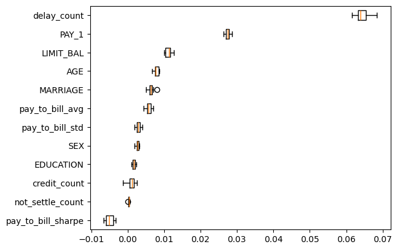

```python
sorted_idx = importances_df.index[::-1]

plt.boxplot(
    pi['importances'][sorted_idx].T,
    vert=False,
    labels=X_train_sub.columns[sorted_idx]
)

df_perm_importances = pd.DataFrame({"feats": X_train.columns[sorted_idx],
                                         "importances": pi["importances_mean"][sorted_idx]})
df_perm_importances = df_perm_importances.sort_values(by=["importances"], ascending=False)
df_perm_importances.style.background_gradient(axis=0)
```

**2. Summarize the observations.**

In terms of permutation importance, `delay_count`, which is the number of delayed payments, is the most important. In other words, permuting this feature provides the most impact on the prediction of the model. The second most important feature is `PAY_1`, i.e. the most recent repayment status in the dataset.

These two features are clearly the most important, and stand out from the rest of the features.

## 12. Results on the test set

rubric={accuracy,reasoning}

**Your tasks:**

1. Try your best performing model on the test data and report test scores.
2. Do the test scores agree with the validation scores from before? To what extent do you trust your results? Do you think you've had issues with optimization bias?
3. Take one or two test predictions and explain them with SHAP force plots.

*Points:* 6

```python
# 1. Try the optimized LightGBM model on the test data and report test scores.
lgbm_rs.score(X_test, y_test)
```

```
0.5271565495207666
```

The test score is 0.527, which agrees with the validation score of 0.527. It does not seem that the model is having issues with optimization bias due to its similar validation and test scores. We trust that the test score provides a good representation of the model's performance since the test data is of decent size.

The force plot shows that the model's score is higher than the base score. More specifically, `delay_count = 4` (with an importance score of 1.31) and `PAY_1 = 4` (with an importance score of 0.97) are the most significant in pushing the raw prediction score higher. Overall, the importances from all features add up to the final (raw) score predicted by the model.

```python
initjs
```

[output not shown]

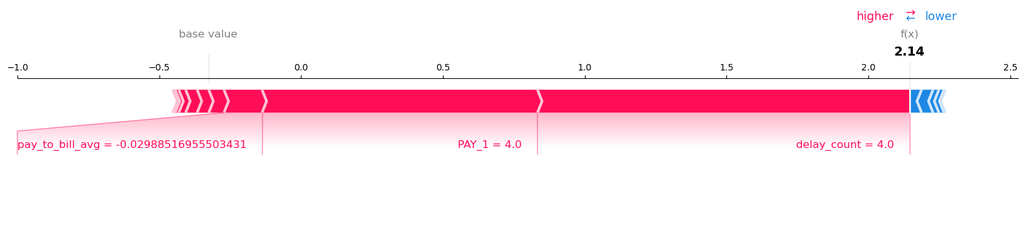

```python
# 3. Take one test prediction and explain them with SHAP force plots.
shap.initjs() # load JS visualization code to notebook

# Extract fitted transformer
fitted_preprocesor = best_lgbm_pipe.named_steps['columntransformer']

# Extract transformed features
enc_feat = []
for transformer in fitted_preprocesor.named_transformers_.values():
    if transformer == 'drop':
        continue
    enc_feat += transformer.get_feature_names_out().tolist()

# Transform X_test
X_test_enc = pd.DataFrame(
    fitted_preprocesor.transform(X_test),
    columns=enc_feat,
    index=X_test.index,
)

#  Prepare SHAP force plots
lgbm_explainer = shap.TreeExplainer(best_lgbm_pipe.named_steps["lgbmclassifier"])

lgbm_explanation = lgbm_explainer(X_test_enc)
lgbm_explanation
shap.plots.force(lgbm_explanation[21, :, 1], matplotlib=True)
```

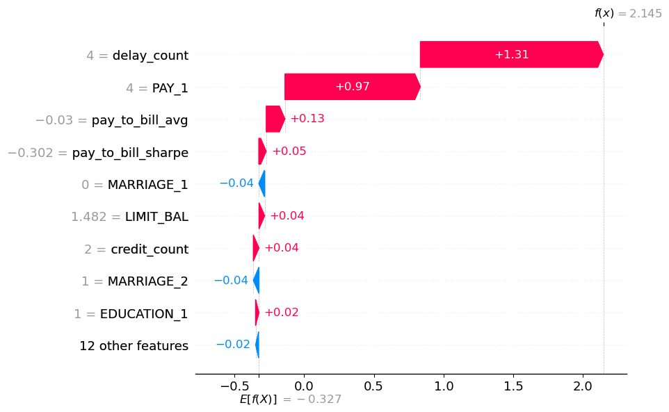

```python
shap.plots.waterfall(lgbm_explanation[21, :, 1])
```

## 13. Summary of results

rubric={reasoning}

Imagine that you want to present the summary of these results to your boss and co-workers.

**Your tasks:**

1. Create a table summarizing important results.
2. Write concluding remarks.
3. Discuss other ideas that you did not try but could potentially improve the performance/interpretability .
4. Report your final test score along with the metric you used at the top of this notebook.

*Points:* 8

```
<sklearn.metrics._plot.confusion_matrix.ConfusionMatrixDisplay at 0x1533b75d0>
```

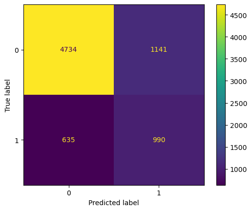

```python
#Confusion Matrix
ConfusionMatrixDisplay.from_estimator(
    lgbm_rs,
    X_test,
    y_test
)
```

```python
#Classification Report
print(
    classification_report(
        y_test, lgbm_rs.predict(X_test)
    )
)
```

```
              precision    recall  f1-score   support

           0       0.88      0.81      0.84      5875
           1       0.46      0.61      0.53      1625

    accuracy                           0.76      7500
   macro avg       0.67      0.71      0.68      7500
weighted avg       0.79      0.76      0.77      7500
```

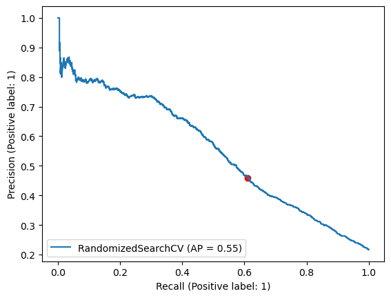

```python
#Precision Recall-Curve
recall = 0.61
precision = 0.46

PrecisionRecallDisplay.from_estimator(
    lgbm_rs,
    X_test,
    y_test,
);

plt.scatter(
    x=recall,
    y=precision,
    color='red',
);
```

2. By looking at the graph, we can see that the model's performance is far from optimal, which is illustrated by the AP score of 0.55. We could decrease the threshold to improve recall, however, this would require significant sacrifices in precision. The classification reveals less than optimal recall score of 0,61 with lots of room for improvement.

`delay_count` and `PAY_1` are the most influential features in pushing the prediction away from the mean towards to the model's actual predicted value.

3. We should communicate with experts from the financial fields as well as the data collectors. Another limitation is that we did not consider the sequential nature of the data, since we have 6 observations of a few same metrics over a period of 6 months. One potential improvement is to use a recurrent neural network to process such features in a sequential manner.

```python
lgbm_rs.score(X_test, y_test)
```

```
0.5271565495207666
```

4. The f1 score on the test data is similar to the one we got from cross validation, which is an indicator for a model that is robust but suboptimal in terms of performance.

## 14. Creating a data analysis pipeline (Challenging)

rubric={reasoning}

**Your tasks:**

- Convert this notebook into scripts to create a reproducible data analysis pipeline with appropriate documentation. Submit your project folder in addition to this notebook on GitHub and briefly comment on your organization in the text box below.

*Points:* 2

## 15. Your takeaway from the course (Challenging)

rubric={reasoning}

**Your tasks:**

What is your biggest takeaway from this course?

*Points:* 0.25

Particularly interesting is the concept of SHAP values, which gives you an idea of the feature importance in an individual prediction. Thus, it is a great tool that complements permutation importance, which provides an overall picture of feature importance. There are also helpful visualizations for illustrating these tools.

**Restart, run all and export a PDF before submitting**

Before submitting, don't forget to run all cells in your notebook to make sure there are no errors and so that the TAs can see your plots on Gradescope. You can do this by clicking the ▶▶ button or going to `Kernel -> Restart Kernel and Run All Cells...` in the menu. This is not only important for MDS, but a good habit you should get into before ever committing a notebook to GitHub, so that your collaborators can run it from top to bottom without issues.

After running all the cells, export a PDF of the notebook (preferably the WebPDF export) and upload this PDF together with the ipynb file to Gradescope (you can select two files when uploading to Gradescope)

## Help us improve the labs

The MDS program is continually looking to improve our courses, including lab questions and content. The following optional questions will not affect your grade in any way nor will they be used for anything other than program improvement:

1. Approximately how many hours did you spend working or thinking about this assignment (including lab time)?

# Ans:

2. Do you have any feedback on the lab you be willing to share? For example, any part or question that you particularly liked or disliked?

# Ans: